# Microbiome and DESeq2

Exploring ecology - microbiome landscaping: https://academic.oup.com/femsre/article/41/2/182/2979411#58802539

When using these tools, kindly cite: *Shetty et al. FEMS Microbiology Reviews, 41(2):182-199, 2017* Will do!

This is an extension of ordination methods

```r
#Load up ggplot2 and phyloseq
library(microbiome)
library(knitr)
library(ggplot2)
library(phyloseq)
#load data
data(dietswap)
pseq <- dietswap
# Convert to compositional data
pseq.rel <- microbiome::transform(pseq, "compositional")
# Pick core taxa with with the given prevalence and detection limits
pseq.core <- core(pseq.rel, detection = .1/100, prevalence = 90/100)
# Use relative abundances for the core
pseq.core <- microbiome::transform(pseq.core, "compositional")
#look at meta data
meta <- meta(pseq)
head(meta)
```

|  | subject | sex | nationality | group | sample | timepoint | timepoint.within.group | bmi_group |
| --- | --- | --- | --- | --- | --- | --- | --- | --- |
| Sample-1 | byn | Male | AAM | DI | Sample-1 | 4 | 1 | obese |
| Sample-2 | nms | Male | AFR | HE | Sample-2 | 2 | 1 | lean |
| Sample-3 | olt | Male | AFR | HE | Sample-3 | 2 | 1 | overweight |
| Sample-4 | pku | Female | AFR | HE | Sample-4 | 2 | 1 | obese |
| Sample-5 | qjy | Female | AFR | HE | Sample-5 | 2 | 1 | overweight |
| Sample-6 | riv | Female | AFR | HE | Sample-6 | 2 | 1 | obese |

Sample ordination Project the samples with the given method and dissimilarity measure.

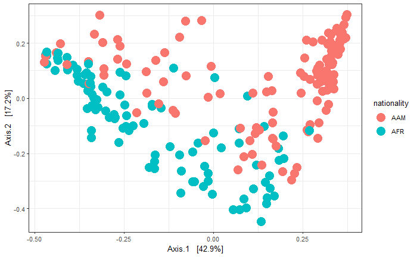

```r
# Ordinate the data
set.seed(4235421)
# proj <- get_ordination(pseq, "MDS", "bray")
ord <- ordinate(pseq, "MDS", "bray")
#Try MDS/PCoA by nationality
plot_ordination(pseq, ord, color = "nationality") +
                geom_point(size = 5)
```

Not bad, let’s try by other attributes

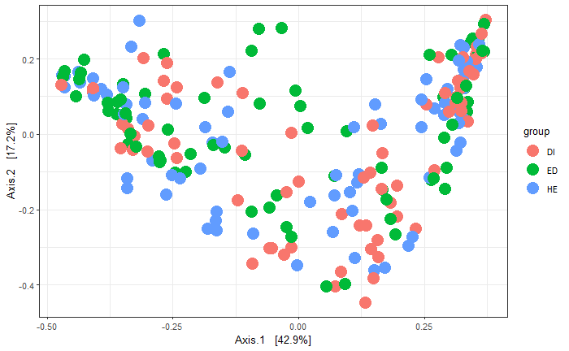

```r
#group
plot_ordination(pseq, ord, color = "group") +
                geom_point(size = 5)
```

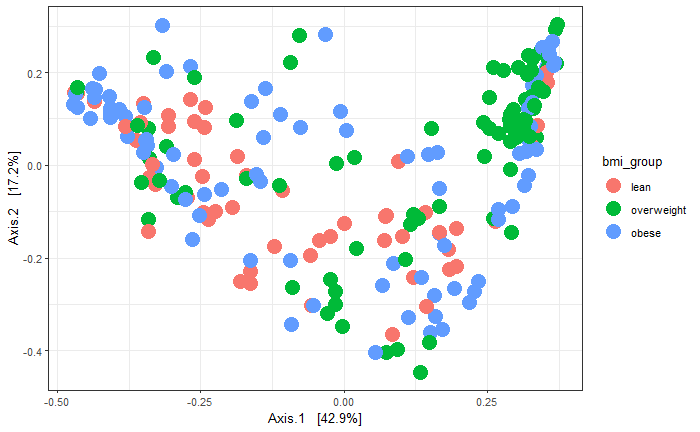

```r
#BMI
plot_ordination(pseq, ord, color = "bmi_group") +
                geom_point(size = 5)
```

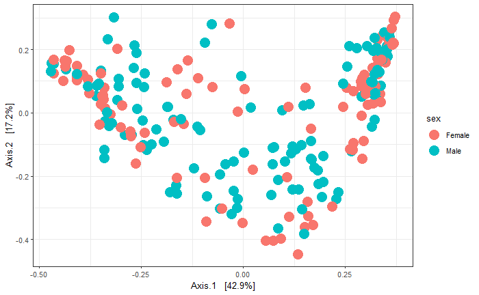

```r
#Gender
plot_ordination(pseq, ord, color = "sex") +
                geom_point(size = 5)
```

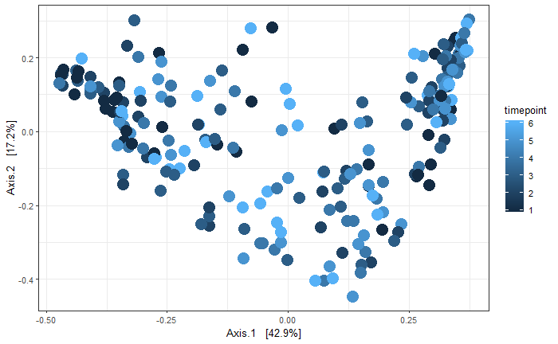

```r
#timepoint
plot_ordination(pseq, ord, color = "timepoint") +
                geom_point(size = 5)
```

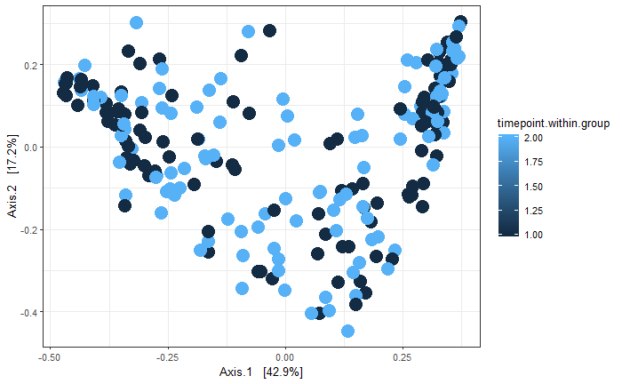

```r
#timepoint.within.group
plot_ordination(pseq, ord, color = "timepoint.within.group") +
                geom_point(size = 5)
```

Of all these, nationality seems to give the cleanest separation.

I’d like to see which taxa are most differential between different nationalities. I’m going to use DESeq2 functionality in phyloseq based on this tutorial: http://joey711.github.io/phyloseq-extensions/DESeq2.html

```r
head(sample_data(pseq)$nationality, 25)
```

```
 [1] AAM AFR AFR AFR AFR AFR AFR AFR AFR AFR AFR AFR AFR AFR AFR AFR AFR AFR AFR AFR AFR AFR AFR AFR AFR
Levels: AAM AFR
```

It looks like everything is labeled, which is good. Otherwise I’d have to account for unlabeled data.

Now load DESeq2. Install from bioclite if needed.

```r
library("DESeq2")
```

The following two lines actually do all the complicated DESeq2 work. The function phyloseq_to_deseq2 converts your phyloseq-format microbiome data into a DESeqDataSet with dispersions estimated, using the experimental design formula, also shown (the ~nationality term). The DESeq function does the rest of the testing, in this case with default testing framework, but you can actually use alternatives.

```r
nat_ds <- phyloseq_to_deseq2(pseq, ~ nationality)
nat_ds <- DESeq(nat_ds, test="Wald", fitType="parametric")
```

```
-- note: fitType='parametric', but the dispersion trend was not well captured by the
   function: y = a/x + b, and a local regression fit was automatically substituted.
   specify fitType='local' or 'mean' to avoid this message next time.
-- replacing outliers and refitting for 30 genes
-- DESeq argument 'minReplicatesForReplace' = 7
-- original counts are preserved in counts(dds)
```

```r
res <- results(nat_ds, cooksCutoff = FALSE)
alpha <- 0.01
sigtab <- res[which(res$padj < alpha), ]
sigtab <- cbind(as(sigtab, "data.frame"), as(tax_table(pseq)[rownames(sigtab), ], "matrix"))
head(sigtab)
```

|  | baseMean | log2FoldChange | lfcSE | stat | pvalue | padj | Phylum | Genus |
| --- | --- | --- | --- | --- | --- | --- | --- | --- |
| Akkermansia | 7074.331655 | -1.1181811 | 0.2248408 | -4.973213 | 6.585224e-07 | 1.528713e-06 | Verrucomicrobia | Akkermansia |
| Allistipes et rel. | 17253.612854 | -2.7239751 | 0.1591488 | -17.115898 | 1.129596e-65 | 3.671187e-64 | Bacteroidetes | Allistipes et rel. |
| Anaerobiospirillum | 1.832009 | 0.6681180 | 0.2145944 | 3.113398 | 1.849462e-03 | 3.243297e-03 | Proteobacteria | Anaerobiospirillum |
| Anaerofustis | 3.816405 | -0.8372116 | 0.2448440 | -3.419367 | 6.276697e-04 | 1.182566e-03 | Clostridium cluster XV | Anaerofustis |
| Anaerostipes caccae et rel. | 4201.311934 | -1.5851909 | 0.1541558 | -10.283044 | 8.403107e-25 | 6.827524e-24 | Clostridium cluster XIVa | Anaerostipes caccae et rel. |
| Anaerotruncus colihominis et rel. | 4662.133057 | 0.6594662 | 0.1926501 | 3.423130 | 6.190447e-04 | 1.182566e-03 | Clostridium cluster IV | Anaerotruncus colihominis et rel. |

```r
sigtab <- sigtab[order(sigtab$Phylum),]
head(sigtab)
```

|  | baseMean | log2FoldChange | lfcSE | stat | pvalue | padj | Phylum | Genus |
| --- | --- | --- | --- | --- | --- | --- | --- | --- |
| Bifidobacterium | 4746.701630 | -0.55686521 | 0.19331001 | -2.880685 | 3.968123e-03 | 6.448200e-03 | Actinobacteria | Bifidobacterium |
| Collinsella | 782.322022 | 1.13966011 | 0.15977125 | 7.133074 | 9.815206e-13 | 4.253256e-12 | Actinobacteria | Collinsella |
| Eggerthella lenta et rel. | 306.379747 | 0.28408606 | 0.05944523 | 4.778954 | 1.762093e-06 | 3.882577e-06 | Actinobacteria | Eggerthella lenta et rel. |
| Propionibacterium | 81.541307 | -0.39480806 | 0.03727524 | -10.591698 | 3.256308e-26 | 2.822133e-25 | Actinobacteria | Propionibacterium |
| Aneurinibacillus | 2.032135 | 1.25786328 | 0.19929560 | 6.311546 | 2.762625e-10 | 9.976146e-10 | Bacilli | Aneurinibacillus |
| Bacillus | 71.852145 | -0.08530259 | 0.03122416 | -2.731942 | 6.296223e-03 | 9.861553e-03 | Bacilli | Bacillus |

Let’s see if these can be visualized.

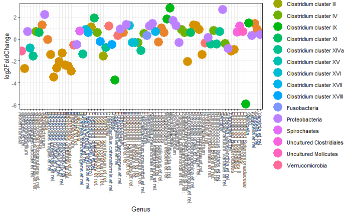

```r
ggplot(sigtab, aes(x=Genus, y=log2FoldChange, color=Phylum)) + geom_point(size=6) +
  theme(axis.text.x = element_text(angle = -90, hjust = 0, vjust=0.5))
```

Hmm, I bet there’s a way to make this more informative, but in its current state I don’t find it useful.

Rather, I think I want to subset the initial data for the most differential taxa for visualization. First, ‘Uncultured Selenomonadaceae’, which scored most negative fold change by nationality.

```r
UncSel <- subset_taxa(pseq, Genus %in% c('Uncultured Selenomonadaceae'))
summarize_phyloseq(UncSel)
```

```
Compositional = NO
1] Min. number of reads = 1
2] Max. number of reads = 3684
3] Total number of reads = 23037
4] Average number of reads = 103.77027027027
5] Median number of reads = 1
7] Sparsity = 0
6] Any OTU sum to 1 or less? NO
8] Number of singletons = 0
9] Percent of OTUs that are singletons 0
10] Number of sample variables are: 8
subject
sex
nationality
group
sample
timepoint
timepoint.within.group
bmi_group
```

Great, now let’s plot it with the built-in function plot_bar.

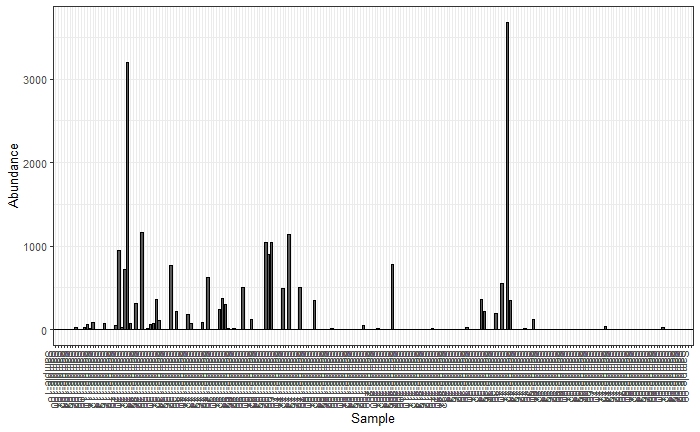

```r
plot_bar(UncSel)
```

That’s not very informative, let’s get more specific.

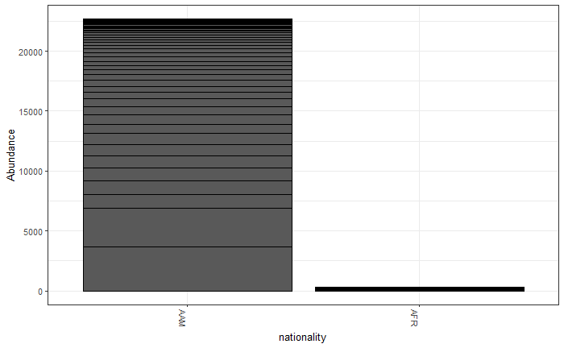

```r
plot_bar(UncSel, x="nationality")
```

This doesn’t look like nice, I’m going to try a different layout. Perhaps a swarm plot, with a log-transformed axis.

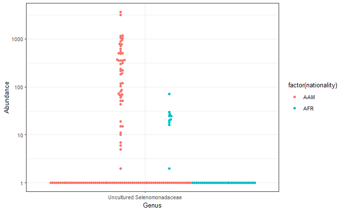

```r
df <- psmelt(UncSel) # transform to dataframe for ggplot
library(ggbeeswarm) # load beeswarm package
ggplot(df, aes(Genus, Abundance, color=factor(nationality))) + geom_beeswarm(dodge.width=0.5) + scale_y_log10()
```

I’m happy with that. Interesting that there are a ton of low-abundance hits. I would think it would be valuable to filter hits based on prevalance as well as abundance.

Next, I want to plot the genus that had the largest lfc, ‘Mitsuokella multiacida et rel.’

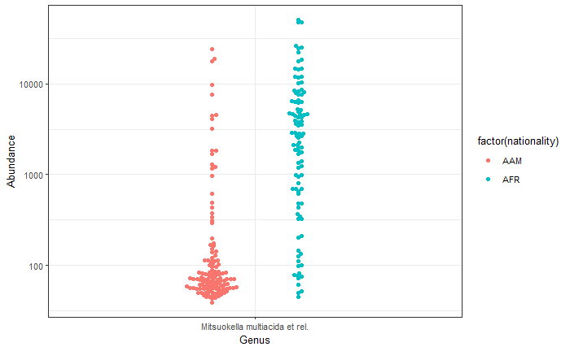

```r
Mitsu <- subset_taxa(pseq, Genus %in% c('Mitsuokella multiacida et rel.'))
df <- psmelt(Mitsu) # transform to dataframe for ggplot
ggplot(df, aes(Genus, Abundance, color=factor(nationality))) + geom_beeswarm(dodge.width=0.5) + scale_y_log10()
```

Fantastic! These samples all have >10 hits, with a clearly higher mean in the AFR group compared to the AAM group.

Finally, I’d like to try a faceted swarm plot for everything with > or < 1.5- log2fc. Moreover, it’ll be faceted on the basis of phylum, to see if there’s any higher level trends. This will be easiest if I filter the sigtab call, then pass the selected genus to the subset_taxa call, then pass to swarm plot with facet.

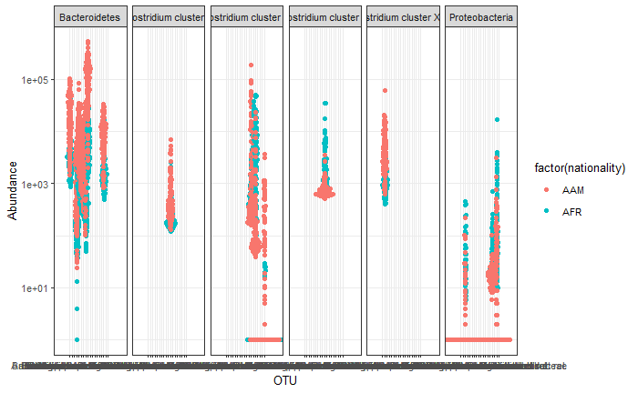

```r
fc_filtered <- sigtab[abs(sigtab$log2FoldChange)>1.5,]$Genus
sig_taxa <- subset_taxa(pseq, Genus %in% fc_filtered)
df <- psmelt(sig_taxa) # transform to dataframe for ggplot
ggplot(df, aes(OTU, Abundance, color=factor(nationality))) +
  geom_beeswarm(dodge.width=0.5) +
  scale_y_log10() +
  facet_grid(. ~ Phylum)
```

It looks like the AAM group has much higher abundances of several Bacteroidetes and some of the Clostridium clusters, while the AFR group has higher abundances of Proteobacteria.

As a primer I felt this was very informative. I think moving forward I need to read up on what some of the conventions are with respect to reporting. Also, given the scale of abundance data, I would think something like log10 transforming the data might be helpful.

My next project on this subject will be exploring some datasets that combine metabolomics and metagenomics. I would like to see what tools are currently available for looking at genome information and linking that to metabolomic data. I’d also like to explore some disease case/control datasets and see if machine learning can be applied to predict disease and/or outcome.